# ggplot: spatial

Olivia Burge

12 October 2014

# Mapping, animals and corr plots (2)

# Maps: base plot and ggplot

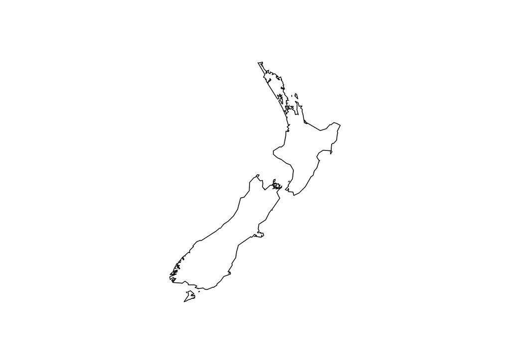

```r
map('nz')
```

```r
# or:
nzmap <- map_data('nz')
head(nzmap)
```

```
##    long    lat group order        region subregion
## 1 172.7 -34.44     1     1 North.Island       <NA>
## 2 172.8 -34.46     1     2 North.Island       <NA>
## 3 172.9 -34.45     1     3 North.Island       <NA>
## 4 172.9 -34.42     1     4 North.Island       <NA>
## 5 173.0 -34.43     1     5 North.Island       <NA>
## 6 173.0 -34.40     1     6 North.Island       <NA>
```

Now for ggplot - try the first map

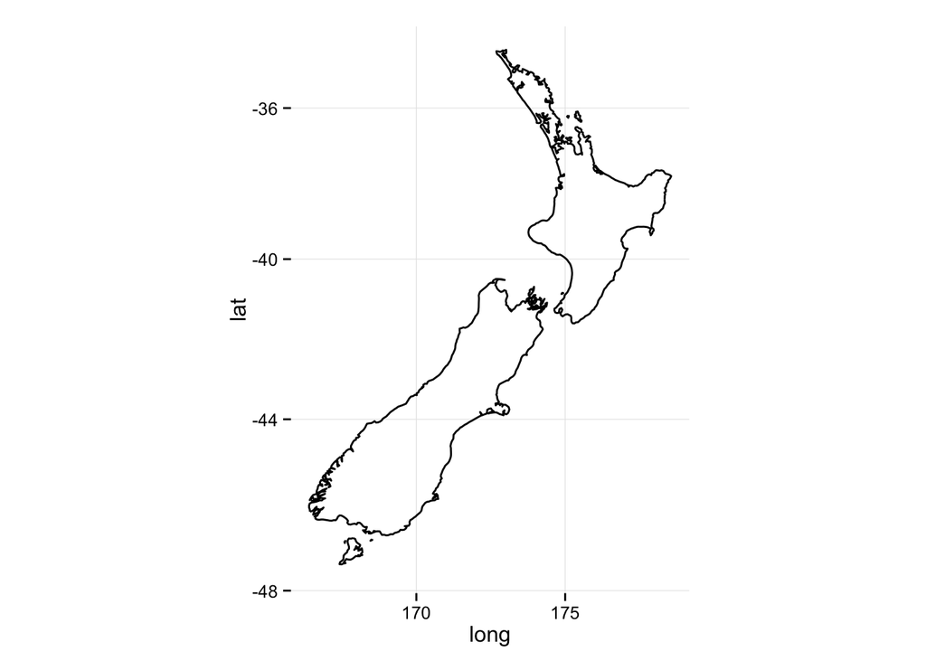

```r
map1 <- ggplot(nzmap, aes(x = long, y = lat, group = group)) +
  geom_polygon()
map1

# hmmm. change polygon to path, and add coord_map

map2 <- ggplot(nzmap, aes(x = long, y = lat, group = group)) +
  geom_path() +
  coord_map() +
  theme_minimal()
map2
```

[output not shown]

Next up is getting the google map:

```r
ggnz<-get_map('nz', source='google', maptype='road',
              zoom = 5)
```

```
## Google Maps API Terms of Service : http://developers.google.com/maps/terms
## Google Maps API Terms of Service : http://developers.google.com/maps/terms
```

[figure not shown]

```r
map3 <-ggmap(ggnz)
map3
```

# Adding location data to maps:

Firstly, we get some data. We are first trying the RCurl package to get the data off a github site (mine, in fact). It’s freely available on the web, but I’ve added it here for ease of access.

If this doesn’t work, uncomment the lines below where the data is entered manually (and correctly, hopefully!). Note that if you highlight the commented lines and go up to the “Code” menu option you can ‘uncomment’ them all at once.

## data

```r
# get data




url_kakariki <- getURL("https://raw.githubusercontent.com/orb16/seminaRs/master/Ashburton%20lakes.csv",
    ssl.verifypeer = FALSE)

awaraikakariki <- read.csv(text = url_kakariki, header = TRUE, stringsAsFactors = FALSE,
    fileEncoding = "latin1")
awaraikakariki <- awaraikakariki[c("site", "lat", "lon")]

url_ramsar <- getURL("https://raw.githubusercontent.com/orb16/seminaRs/master/Ramsar%20sites.csv",
    ssl.verifypeer = FALSE)

ramsar <- read.table(text = url_ramsar, sep = ",", stringsAsFactors = FALSE,
    fileEncoding = "latin1", header = T)
ramsar <- ramsar[c("site", "lat", "lon")]

# awaraikakariki <- data.frame(site = c('Ashburton lakes', 'Awarua-Waituna
# Wetland', 'Whangamarino'), lat = c(-43.56417, -46.56667, -37.30000), lon =
# c(171.1892, 168.5167, 175.1167))

# ramsar <- data.frame( site = c('Awarua Wetland (formerly Waituna Lagoon)',
# 'Farewell Spit', 'Whangamarino', 'Kopuatai Peat Dome', 'Firth of Thames',
# 'Manawatu river mouth and estuary'), lat = c(-46.56666667, -40.53333333,
# -37.3, -37.43333333, -37.21666667, -40.48333333), lon = c(168.5166667,
# 172.8333333, 175.1166667, 175.55, 175.3833333, 175.2333333) )
```

## base graphics method

This is going to save your map as “foo.png” to whichever working directory you have (NB, it will likely be where you’ve saved this .Rmd file, unless you set it explicitly.)

```r
png("foo.png", height= 640, width= 480)
map('nz')
points(x = ramsar$lon, y = ramsar$lat, pch = 16, col="slateblue4")
dev.off()
```

```r
# prints with a white background.
#try making a transparent one adding "bg = transparent" to png()
```

## ggplot method

And with ggplot. Here we `rbind` the data. This is like `merge`, but since we have all the same column names and number of columns, we can `rbind`. `Rbind` is like gluing one dataset below the other, and just dropping one of the header columns (hence having to have same number and names of cols).

```r
ramsar$data <- "Ramsar wetlands"
awaraikakariki$data <- "Arawai kakariki wetlands"
```

This part above makes a new factor in each dataset, before we `rbind` them. Have a look to see the before and after.

```r
nzwetlands <- rbind(ramsar, awaraikakariki)
```

The map: a lot of code. But if you go through line by line, nothing too scary. The `facet_wrap()` is what makes two maps, splitting on the variable we created earlier. All the `theme` stuff at the end is mainly to make it transparent, and to get rid of the lines behind the plot. `strip.text` changes the size of the text in the headers at the top.

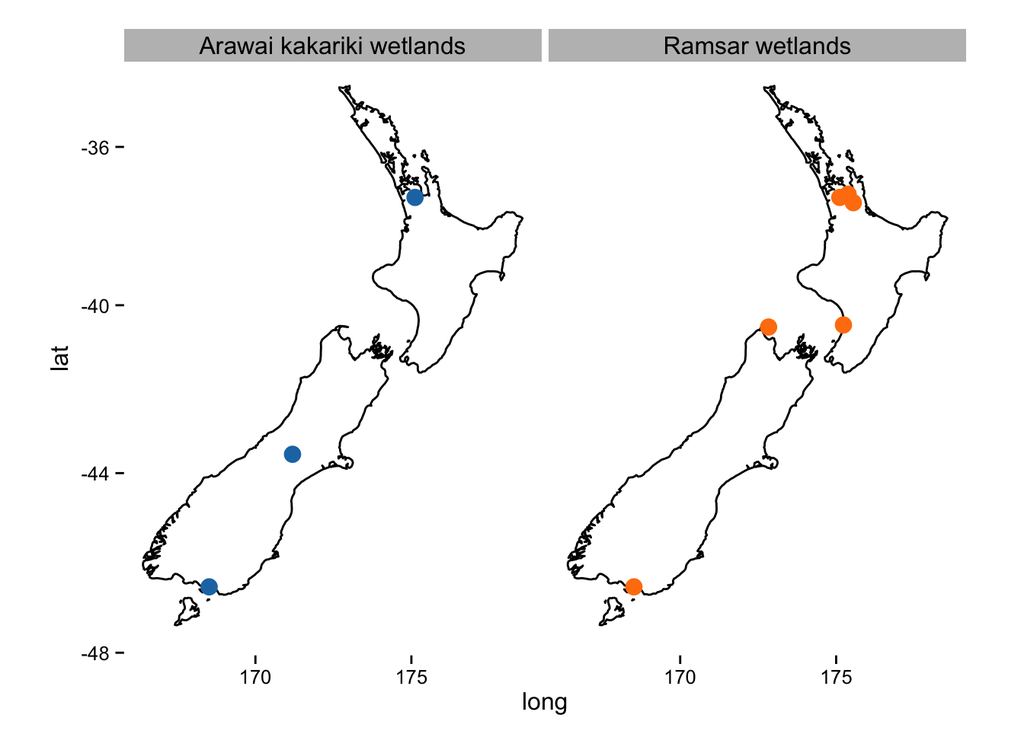

```r
map_bg <- ggplot(nzmap, aes(x = long, y = lat)) +
   geom_path(aes(group = group)) +
   coord_map() +
   geom_point(data = nzwetlands,
              size = 4,
              aes(x = lon, y = lat, colour = data)) +
   scale_colour_tableau(guide = FALSE) +
   facet_wrap(~ data) +
   theme_minimal() +
   theme(strip.text = element_text(size = 12),
         strip.background = element_rect(fill = "grey", colour = NA),
         panel.grid.major = element_blank(),
         panel.grid.minor = element_blank(),
         panel.background = element_rect(fill = "transparent",
                                         colour = NA),
         plot.background = element_rect(fill = "transparent",
                                        colour = NA))

ggsave(plot = map_bg, "map_bg.png", bg = "transparent")
map_bg
```

```r
#this is for a transparent map.
#Delete all the references to transparent to get a white bg.
```

# Plotting shapefile data

NB, the maps sourced from `get_map()` or `get_stamenmap` are just images underlaid on the plot. If you try to plot a south island map you’ve extracted from there withe the forest data (below), you will see the problem. To save downloading, you will load the .Rdata file into you working directory, and then source it. Alternatively, set the full file path in the load command.

If you are interested in how to read in the data, have a look at the source file for this document, which prints the code I used. You’ll need to get the raw data from koordinates.com

## the forests

Because you won’t be able to install `readogr`, I’ve saved the results as a datafile for you to load. You’ll need to save this and then change the path, below.

```r
#save(forests_df, coast, file = "sem6_GIS.Rdata")
load("/Users/Liv/sem6_GIS.Rdata")
```

## Polygon of the South Island

Next up we plot just the South Island, and Stewart Island (this is what the `coast[]` part is doing)

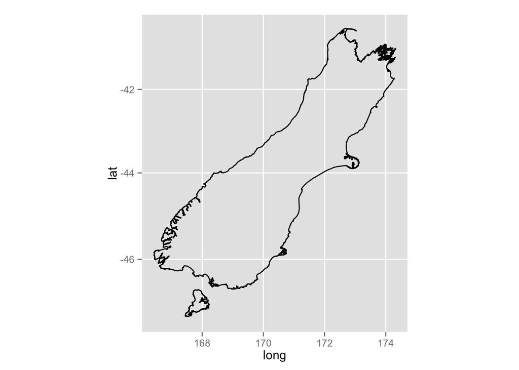

```r
#base layer and forest data are from
# koordinates.com - worth a look, quite a bit of data

base_nz<-ggplot(data = coast[coast$id %in% c(2, 0),], aes(x=long, y = lat))+
  geom_path(aes(group = group)) +
  coord_map()
base_nz
```

## Forest polygons

Now that that works, we can overlay the polygons. This takes ages, hence getting the map together first, and also, save other things before you run this.. You have been warned!

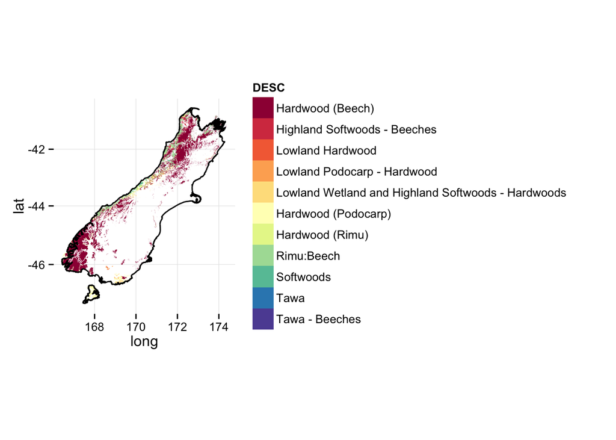

```r
(base_forest <-  ggplot(data = coast[coast$id %in% c(2, 0),],
                        aes(x=long, y = lat))+
  theme_minimal() +
  geom_polygon(data = forests_df,
               aes(y = lat, x = long, group = group, fill = DESC)) +
  geom_path(aes(group = group)) +
  coord_map()+
  scale_fill_brewer(palette = "Spectral"))
```

```r
  ggsave(base_forest, file = "base_forest.pdf",
         width = 210, height = 297, units = "mm")

# can do other things - source some contours, for example.
```

This work is licensed under the Creative Commons Attribution-NonCommercial-ShareAlike 4.0 International License. To view a copy of this license, visit http://creativecommons.org/licenses/by-nc-sa/4.0/ or send a letter to Creative Commons, PO Box 1866, Mountain View, CA 94042, USA.